# Philadelphia Crime and Lead Levels

Ashlin Oglesby-Neal

May 3, 2018

## Prepare Workspace

### Load packages

```r
library(tidyverse)
library(readr)
library(lubridate)
library(rgdal)
library(skimr)
library(tigris)
library(tidycensus)
library(stargazer)
```

### Load Data

This project uses two data sets from opendataphilly.org. One is all crime incidents reported by the Philadelphia Police Department and the other is information on children screened for elevated blood lead levels from the Philadelphia Department of Public Health.

```r
# crime
phl <- read_csv("incidents_part1_part2.csv")

# lead levels
lead <- read_csv("child_blood_lead_levels_by_ct.csv")
```

## Prepare Data

### Map Philadelphia Crime

Almost every crime incident in Philadelphia has a latitude and longitude. The information on lead levels is at the census tract level. Crime incidents are mapped over a shapefile of Philadelphia block groups, so that they can be aggreagated to the census tract level.

```r
#add census block group
bgroup.phl <- block_groups(state = "PA", county="101")
```

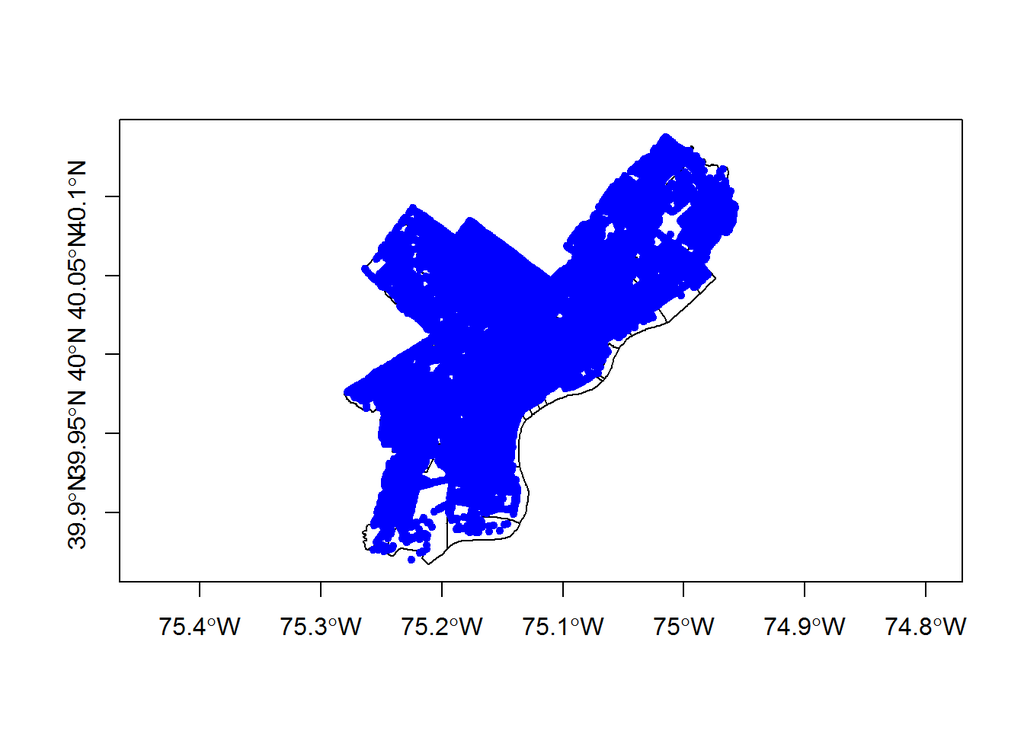

```r
bgroup.phl <- spTransform(bgroup.phl, CRS("+proj=longlat +lat_1=39.93333333333333
   +lat_2=40.96666666666667 +lat_0=39.33333333333334
   +lon_0=-77.75 +x_0=600000 +y_0=0 +datum=NAD83
   +units=us-ft +no_defs +ellps=GRS80 +towgs84=0,0,0"))

# plot all PHL crime
phl2 <- filter(phl, !is.na(lat) & !is.na(lng))
plot(bgroup.phl,axes=TRUE)
points(phl2$lng,phl2$lat,col="blue",pch=20)
```

```r
b <- SpatialPoints(phl2[,c("lng","lat")],
                   proj4string=bgroup.phl@proj4string)

# match each polygon in PHL map to each point
bgroup_lookup2 <- over(b, bgroup.phl)
bgroup_lookup2[1:3,]
```

```
##   STATEFP COUNTYFP TRACTCE BLKGRPCE        GEOID      NAMELSAD MTFCC
## 1      42      101  003001        3 421010030013 Block Group 3 G5030
## 2      42      101  003901        1 421010039011 Block Group 1 G5030
## 3      42      101  003901        3 421010039013 Block Group 3 G5030
##   FUNCSTAT  ALAND AWATER    INTPTLAT     INTPTLON
## 1        S  48136      0 +39.9284555 -075.1721526
## 2        S 114949      0 +39.9251855 -075.1712223
## 3        S 115111      0 +39.9218853 -075.1751949
```

```r
phl2$bgroup <- bgroup_lookup2$GEOID
phl2$ctract <- bgroup_lookup2$TRACTCE
phl2$aland <- bgroup_lookup2$ALAND

phl2 <- phl2 %>%
  select(-c(the_geom, the_geom_webmercator)) %>%
  mutate(date = ymd(dispatch_date),
         year = year(date))
```

### Aggreagte Crime Data

After matching each crime incident to a census tract, they can be aggreagated to create a measure of total crime. Crime incidents that did not map to census tracts are excluded.

```r
phl_ct3 <- phl2 %>%
  filter(!is.na(ctract) & year < 2018) %>%
  complete(ctract) %>%
  group_by(ctract) %>%
  summarize(Crime = n())
phl_ct3[1:5,]
```

```
## # A tibble: 5 x 2
##   ctract Crime
##    <chr> <int>
## 1 000100  8776
## 2 000200  7856
## 3 000300  8520
## 4 000401  3273
## 5 000402 17967
```

### Clean Lead File

The lead data set includes information on the number of children screened, the number with elevated blood lead levels, and the percentage with elevated levels per census tract. The number of children with high levels is redacted if it is fewer than six and greater than zero. These redacted values were replaced with five to prevent the loss of these census tracts in analysis, making percentage of kids with high lead levels close to zero rather than missing.

```r
lead2 <- lead %>%
  mutate(num_bll_5plus = ifelse(data_redacted==TRUE & is.na(num_bll_5plus),
                                5, num_bll_5plus),
         perc_5plus = ifelse(data_redacted==TRUE & is.na(perc_5plus),
                             (num_bll_5plus/num_screen), perc_5plus),
         ctract = str_extract(census_tract, "......$"))
lead2[1:3,]
```

```
## # A tibble: 3 x 6
##   census_tract data_redacted num_bll_5plus num_screen perc_5plus ctract
##          <dbl>         <lgl>         <dbl>      <int>      <dbl>  <chr>
## 1  42101020000         FALSE            19        108       17.6 020000
## 2  42101028300         FALSE            81        486       16.7 028300
## 3  42101020400         FALSE            39        238       16.4 020400
```

### Merge Crime and Lead Files

```r
phl_crime_lead <- phl_ct3 %>%
  left_join(lead2, by=  "ctract") %>%
  filter(!is.na(perc_5plus)) %>%
  rename(Perc_High_Lead = perc_5plus)
```

### Add ACS Info

Information on population, poverty, residential stability, and housing age is pulled in from the 2016 5-year ACS using the tidycensus pacakge.

```r
acs <- load_variables(2016, "acs5")
acs_vars<- c("B01003_001E", "B05010_002E", "B19119_001E", "B07204_002E", "B25035_001E", "B17001_002E")

phl_vars <- get_acs(geography="tract", state="PA", county="Philadelphia", variables=acs_vars)
phl_acs <- phl_vars %>%
  select(GEOID, variable, estimate) %>%
  spread(variable, estimate) %>%
  rename(Population=B01003_001, Low_Income_Poverty_Ratio=B05010_002,
         Income=B19119_001,
         Same_Residence=B07204_002, House_Built_Yr=B25035_001,
         Poverty_Rate=B17001_002, census_tract=GEOID) %>%
  mutate(census_tract = as.numeric(census_tract),
         Low_Income_Poverty_Ratio = Low_Income_Poverty_Ratio/Population,
         Same_Residence = Same_Residence/Population,
         Poverty_Rate = Poverty_Rate/Population,
         Pop = Population/1000,
         Income = Income/10000)

phl_crime_lead <- phl_crime_lead %>%
  left_join(phl_acs, by="census_tract") %>%
  mutate(Crime_Rate = (Crime/Population)*1000)
```

## Analysis

### Descriptive Statistics

```r
vars <- phl_crime_lead %>%
  select(Crime, Crime_Rate, Perc_High_Lead, Population,
         Poverty_Rate, Same_Residence, House_Built_Yr) %>%
  mutate(Poverty_Rate = Poverty_Rate*100, Same_Residence = Same_Residence*100)
vars <- as.data.frame(vars)
```

In html, stargazer descriptive tablescan be squished. Rates have been changed to be between 0-100 rather than 0-1 so that decimals can be removed from all numbers in the table.

```r
stargazer(vars, title="Descriptive Statistics", digits=0, type="html")
```

**Descriptive Statistics**

| Statistic | N | Mean | St. Dev. | Min | Max |
| --- | --- | --- | --- | --- | --- |
| Crime | 372 | 6,206 | 4,087 | 593 | 27,716 |
| Crime_Rate | 372 | 1,615 | 1,155 | 272 | 10,555 |
| Perc_High_Lead | 372 | 4 | 4 | 0 | 18 |
| Population | 372 | 4,177 | 1,696 | 643 | 9,485 |
| Poverty_Rate | 372 | 25 | 14 | 1 | 61 |
| Same_Residence | 372 | 84 | 9 | 49 | 98 |
| House_Built_Yr | 372 | 1,949 | 13 | 1,939 | 2,011 |

### Correlation

```r
cor(phl_crime_lead$Crime, phl_crime_lead$Perc_High_Lead)
```

```
## [1] 0.4119917
```

```r
cor(phl_crime_lead$Crime_Rate, phl_crime_lead$Perc_High_Lead)
```

```
## [1] 0.3221628
```

### Regression

```r
mod1 <- lm(Crime~Perc_High_Lead, data=phl_crime_lead)
mod2 <- lm(Crime~Perc_High_Lead+Pop+Poverty_Rate+Same_Residence+House_Built_Yr, data=phl_crime_lead)
mod3 <- lm(Crime_Rate~Perc_High_Lead, data=phl_crime_lead)
mod4 <- lm(Crime_Rate~Perc_High_Lead+Poverty_Rate+Same_Residence+House_Built_Yr, data=phl_crime_lead)
```

```r
stargazer(mod1, mod2,
          dep.var.labels = "Crime Count",
          title="Crime Regression Results", no.space=TRUE,
          covariate.labels = c("Percent High Lead", "Population",
                               "Poverty Rate",
                               "Residential Stability", "House Built Year"),
          digits=2, omit.stat = c("f", "adj.rsq"),
          type="html")
```

**Crime Regression Results**

|  | *Dependent variable:* |  |
| --- | --- | --- |
|  | Crime Count |  |
|  | (1) | (2) |
| Percent High Lead | 397.80*** | 106.26** |
|  | (45.74) | (50.12) |
| Population |  | 898.96*** |
|  |  | (93.99) |
| Poverty Rate |  | 12,359.14*** |
|  |  | (1,349.53) |
| Residential Stability |  | -8,416.26*** |
|  |  | (1,882.00) |
| House Built Year |  | -32.44** |
|  |  | (13.96) |
| Constant | 4,608.20*** | 69,213.11** |
|  | (266.67) | (27,325.67) |
| Observations | 372 | 372 |
| R<sup>2</sup> | 0.17 | 0.47 |
| Residual Std. Error | 3,728.92 (df = 370) | 2,995.96 (df = 366) |
| *Note:* | p<0.1; p<0.05; p<0.01 |  |

Lead is significant and associated with an increase in crime.

```r
stargazer(mod3, mod4,
          dep.var.labels = "Crime Rate (per 1,000 people)",
          title="Crime Rate Regression Results",
          no.space=TRUE,
          covariate.labels = c("Percent High Lead", "Poverty Rate",
                               "Residential Stability", "House Built Year"),
          digits=2, omit.stat = c("f", "adj.rsq"),
          type="html")
```

**Crime Rate Regression Results**

|  | *Dependent variable:* |  |
| --- | --- | --- |
|  | Crime Rate (per 1,000 people) |  |
|  | (1) | (2) |
| Percent High Lead | 87.92*** | 37.87** |
|  | (13.43) | (16.52) |
| Poverty Rate |  | 2,843.33*** |
|  |  | (444.43) |
| Residential Stability |  | -3,407.23*** |
|  |  | (607.63) |
| House Built Year |  | -2.17 |
|  |  | (4.60) |
| Constant | 1,261.89*** | 7,847.19 |
|  | (78.31) | (8,997.30) |
| Observations | 372 | 372 |
| R<sup>2</sup> | 0.10 | 0.28 |
| Residual Std. Error | 1,094.97 (df = 370) | 987.53 (df = 367) |
| *Note:* | p<0.1; p<0.05; p<0.01 |  |

Lead is significant and associated with an increase in crime rates.